# HW1_Aritra

Aritra

2023-09-10

```r
#Clearing the global environment
rm(list = ls())
```

```r
#Uploading the dataset
df_t = read.csv('/Users/aritraray/Downloads/train.csv')
```

**Q1 a. What are the types of variable (quantitative / qualitative) and levels of measurement (nominal / ordinal / interval / ratio) for PassengerId and Age?**

1. Age is quantitative and PassengerID is qualitative.
2. The level of measurement for Age is ratio as a person can be ‘elder’ or ‘younger’ to another. Moreover, a person can be twice as old as another, i.e., a meaningful interval. It holds a true zero value as a child cannot have a negative age value.
3. The level of measurement for PassengerID is nominal as it does not follow any ordering and acts as a unique number for the data.

**Q1b. Which variable has the most missing observations?**

Cabin has the maximum number of NA values (687 missing values), followed by Age and Embarked.

```r
#replace blank spaces with NA values
df_t[df_t == "" | df_t == " "]<-NA

#count the number of NA values per variable in a dataframe
colSums(is.na(df_t))
```

```
## PassengerId    Survived      Pclass        Name         Sex         Age
##           0           0           0           0           0         177
##       SibSp       Parch      Ticket        Fare       Cabin    Embarked
##           0           0           0           0         687           2
```

**Q2. Impute missing observations for Age, SibSp, and Parch with the column median (ordinal, interval, or ratio), or the column mode.**

There are no missing values for SibSp and Parch.

```r
#Finding the median and replacing the NA values with the same
df_t$Age[is.na(df_t$Age)] <- median(df_t$Age, na.rm=TRUE)
#df_t$Age[is.na(df_t$SibSp)] <- median(df_t$SibSp, na.rm=TRUE)
#df_t$Age[is.na(df_t$Parch)] <- median(df_t$Parch, na.rm=TRUE)
```

**Q3. Provide descriptive statistics for Age, SibSp, and Parch.**

```r
library(psych) # To avoid running testthat::describe

describe(df_t[c("Age", "SibSp", "Parch")])
```

```
##       vars   n  mean    sd median trimmed mad  min max range skew kurtosis   se
## Age      1 891 29.36 13.02     28   28.83 8.9 0.42  80 79.58 0.51     0.97 0.44
## SibSp    2 891  0.52  1.10      0    0.27 0.0 0.00   8  8.00 3.68    17.73 0.04
## Parch    3 891  0.38  0.81      0    0.18 0.0 0.00   6  6.00 2.74     9.69 0.03
```

**Q4. Provide a cross-tabulation of Survived and Sex. What do you notice?**

1. As seen below, out of 577 males, 468 of them died. (slightly more than 80%).
2. However, only 25% of females passed away.

```r
#Created a table, assigned headers and added margins
table_1 = table(df_t$Survived, df_t$Sex)
names(dimnames(table_1)) <- c("Survived", "Gender")
table_1 <- addmargins(table_1)
table_1
```

```
##         Gender
## Survived female male Sum
##      0       81  468 549
##      1      233  109 342
##      Sum    314  577 891
```

**Q5. Provide notched boxplots for Survived and Age. What do you notice?**

1. Here, the overlaps of the median for each box plot shows strong confidence interval. It appears to be similar for both passengers who survived and those who died.
2. A significant number of outliers can be spotted for passengers above 55 years old who couldn’t survive.

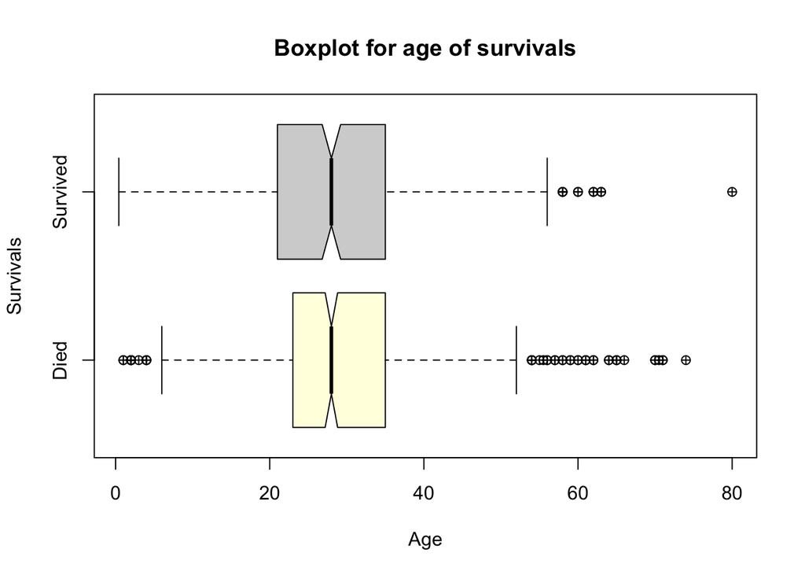

```r
#Created a boxplot
boxplot(df_t$Age ~ df_t$Survived, notch=TRUE,
        ylab='Survivals',
        xlab='Age',
        col=c("light yellow","lightgrey"),
        main='Boxplot for age of survivals',
        horizontal=T,
        pch=10,
        names = c("Died", "Survived"))
```